# Laboratório 5 - Checkpoint 3

Agora vamos continuar usando dados de encotros relâmpago que tínhamos no checkpoint anterior e estaremos ainda fazendo análise de regressão.

A diferença agora é que queremos explicar uma nova variável categórica atrávés de fatores que acreditamos que possam ter influência sobre ela.

A variável que queros explicar é **dec** que diz se p1 gostaria de se encontrar novamente com p2 dado como foi o encontro relâmpago. Podemos entender essa variável como **o match do passado**.

O modelo será gerado utilizando algumas variáveis que acreditamos que tem mais influência sobre a variável resposta e que definem a opinião de um participante sobre o outro. Segundo a perspectiva da pessoa que respondeu o questionário sobre a pessoa com a qual ela acabou de se encontrar são elas:

- **attr**: o quão atraente é a pessoa;
- **sinc**: o quão sincera é a pessoa;
- **intel**: o quão inteligente é a pessoa;
- **fun**: o quão divertida é a pessoa;
- **amb**: o quão ambiciosa é a pessoa;
- **like**: o quanto você gostou da pessoa;
- **prob**: a probabilidade de você querer se encontrar novamente com a pessa.

A seguir, temos uma breve visualização da relação entre cada um dos fatores escolhidos e a variável resposta. Faixas mais escuras indicam maior ocorrência.

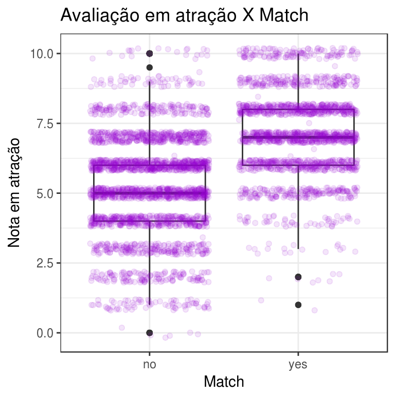

```r
speed_dating <- read_csv("speed-dating2.csv")
dados <- speed_dating %>%
  select(dec, attr, sinc, intel, fun, amb, like, prob) %>%
  mutate(dec = as.factor(dec)) %>%
  na.omit()

attr <- ggplot(dados, aes(x = dec, y = attr)) +
  geom_boxplot() +
  geom_jitter(alpha = 0.1, color="#9400D3") +
  labs(title="Avaliação em atração X Match", x= "Match", y="Nota em atração")

sinc <- ggplot(dados, aes(x = dec, y = sinc)) +
  geom_boxplot() +
  geom_jitter(alpha = 0.1, color="#4B0082") +
  labs(title="Avaliação em sinceridade X Match", x= "Match", y="Nota em sinceridade")

intel <- ggplot(dados, aes(x = dec, y = intel)) +
  geom_boxplot() +
  geom_jitter(alpha = 0.1, color="#0000FF") +
  labs(title="Avaliação em inteligência X Match", x= "Match", y="Nota em inteligência")

fun <- ggplot(dados, aes(x = dec, y = fun)) +
  geom_boxplot() +
  geom_jitter(alpha = 0.1, color="#00FF00") +
  labs(title="Avaliação em divertido(a) X Match", x= "Match", y="Nota em divertido(a)")

amb <- ggplot(dados, aes(x = dec, y = amb)) +
  geom_boxplot() +
  geom_jitter(alpha = 0.1, color="#FFFF00") +
  labs(title="Avaliação em ambicioso(a) X Match", x= "Match", y="Nota em ambicioso(a)")

like <- ggplot(dados, aes(x = dec, y = like)) +
  geom_boxplot() +
  geom_jitter(alpha = 0.2, color="#FF7F00") +
  labs(title="Avaliação em like X Match", x= "Match", y="Nota em like")

prob <-ggplot(dados, aes(x = dec, y = prob)) +
  geom_boxplot() +
  geom_jitter(alpha = 0.2, color="#FF0000") +
  labs(title="Avaliação em chance de reencontro X Match", x= "Match", y="Chance de reencontro")

# grid.arrange(attr, sinc, intel, fun, amb, like, prob)

attr
```

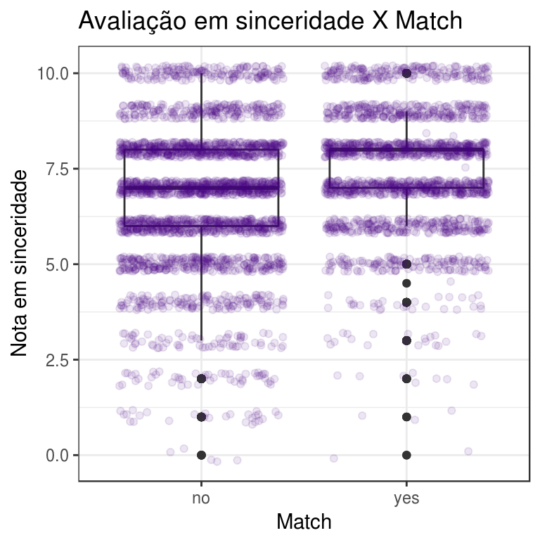

```r
sinc
```

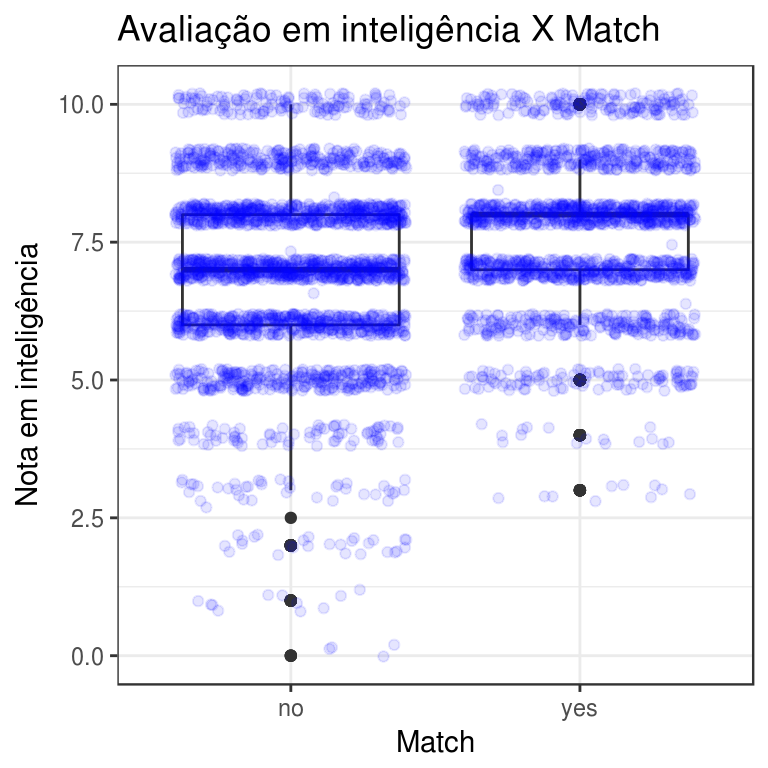

```r
intel
```

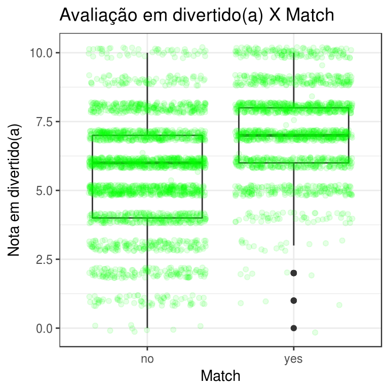

```r
fun
```

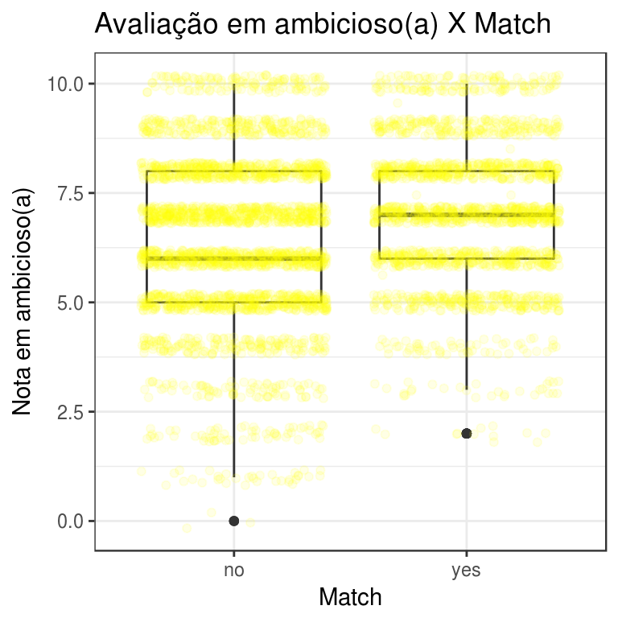

```r
amb
```

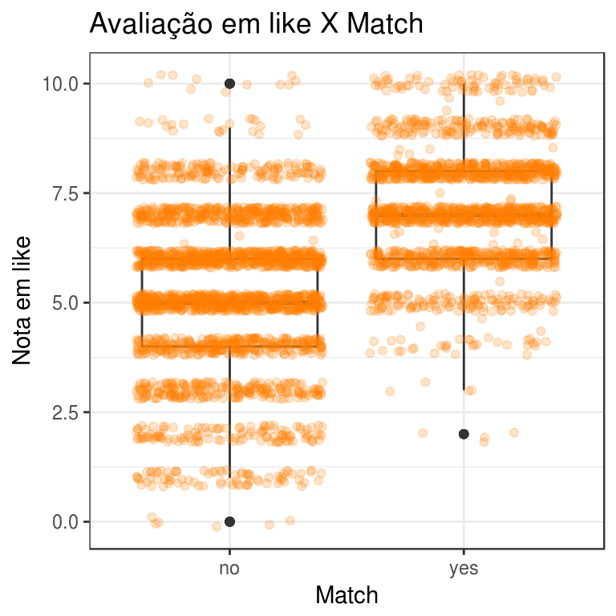

```r
like
```

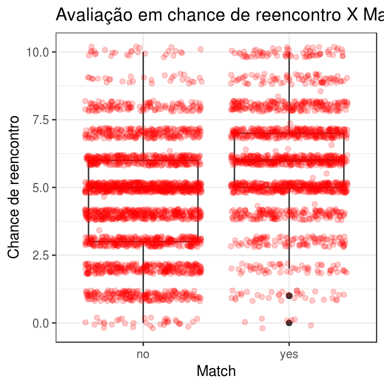

```r
prob
```

Agora que visualizamos as variáveis isoladamente com a variável resposta, iremos gerar um modelo com estas variáveis independentes para observarmos se cada uma delas influencia significativamente a variável resposta e o quão “forte” é essa influência.

Utilizaremos regressão logística para gerar o modelo.

```r
modelo <- glm(dec ~ attr + sinc + intel + fun + amb + like + prob,
              data = dados,
              family = "binomial")
```

# 1. Quais fatores têm efeito significativo na chance de ocorrer match? E como é esse efeito (positivo/negativo)?

```r
tidy(modelo, conf.int = TRUE, exponentiate = TRUE) %>%
  select(-std.error, -p.value) %>%
  datatable()
```

|  | term | estimate | statistic | conf.low | conf.high |
| --- | --- | --- | --- | --- | --- |
| 1 | (Intercept) | 0.00215156126550077 | -23.4382775118804 | 0.00127823934045694 | 0.00357092563726398 |
| 2 | attr | 1.53631198866976 | 14.4886200717499 | 1.45019679832684 | 1.62890445995664 |
| 3 | sinc | 0.796004414101378 | -6.97866595630069 | 0.746351744175259 | 0.848433982158879 |
| 4 | intel | 0.960382262256936 | -1.01420129116946 | 0.888082558358455 | 1.03830745132064 |
| 5 | fun | 1.16846831599273 | 5.03871629850152 | 1.10000852699648 | 1.24169796184159 |
| 6 | amb | 0.844685428813955 | -5.5509883273463 | 0.79562452254086 | 0.896373472052544 |
| 7 | like | 1.93802909381849 | 16.2601346752428 | 1.79100063945368 | 2.10082892740855 |
| 8 | prob | 1.22102204374593 | 9.29872038404689 | 1.17088354260593 | 1.27374701717248 |

Todas as variáveis possuem intervalo de confiança significativo exceto a inteligência, então, nada podemos afirmar sobre a influência desta variável na variavel resposta.

Quanto as demais, de acordo com a tabela acima podemos perceber que sinceridade e ambição tem efeito negativo sobre a chance de match enquanto as demais variáveis tem efeito positivo sobre a chance de ocorrer um match.

# 2. Que fatores nos dados têm mais efeito na chance de ocorrer match?

Ainda segundo a tabela do tópico anterior podemos observar que as variáveis que mais influenciam o match são like, attr respectivamente, ao passo que fun e amb influenciam pouco. Sinc e prob tem influência moderada sobre o match.

# Avaliação do modelo

```r
pR2(modelo)
```

```
##           llh       llhNull            G2      McFadden          r2ML
## -2050.0617177 -2995.3550556  1890.5866757     0.3155864     0.3489645
##          r2CU
##     0.4694585
```

De acordo com a estimativa acima o nosso modelo representa 31% dos dados.

```r
previsoes = modelo %>%
  augment(type.predict = "response") %>%
  mutate(segundo_modelo = .fitted > .5,
         segundo_dados = dec == "yes")

xtabs(~ segundo_modelo + segundo_dados, data = previsoes)
```

```
##               segundo_dados
## segundo_modelo FALSE TRUE
##          FALSE  2081  558
##          TRUE    478 1288
```

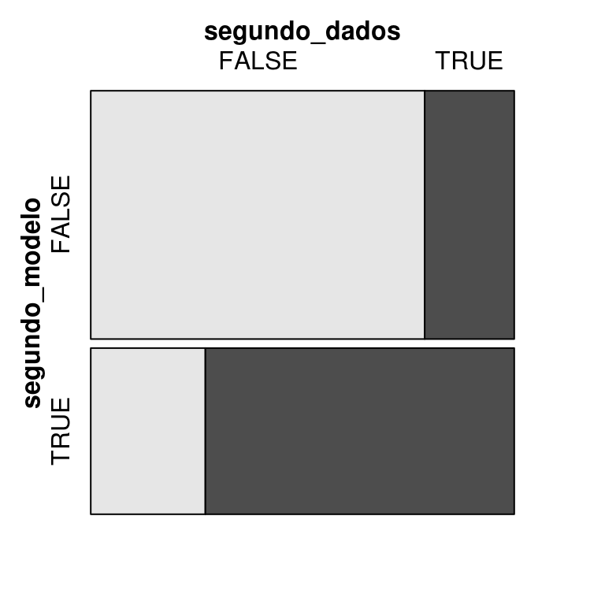

```r
mosaic(segundo_dados ~ segundo_modelo, data = previsoes,
       shade = T)
```

De acordo com a visualização nosso modelo acerta em 76% dos casos.